# MarketRegime-HMM

## Market Regime Classification on Ethereum with Hidden Markov Model

**Brief summary:** In this study, we attempt to study the regime heteroskedasticity on the returns of Ethereum.

Financial time series tend to demonstrate volatility clusterings, large returns typically followed by small returns and vice versa. The heteroskedasticity of variance and the non-normal leptokurtic distribution of financial asset returns are also observed. Similarly, bitcoin was also found to exhibit regime heteroskedasticity.

Given that Ethereum is correlated to bitcoin most of the time, we would like to study the sudden changes in the price dynamics of ethereum through identifying its market regime, and potentially trade with different strategies during different market regimes.

*Note that current work is still in progress*  
**Further work:**

- try different features
- sanity-check each regime
- Incorporate a low-pass filter to identify optimal switching signal.
- back-test strategies for each regime.

**Reference:** 1) Chappell, D. (2018) *Regime heteroskedasticity in Bitcoin: A comparison of Markov switching models.* Available at https://mpra.ub.uni-muenchen.de/90682/ 2) https://medium.com/@matthewwang_91639/algorithmic-factor-investing-with-market-regime-classification-6bc2f8c7168b

```python
import operator
from datetime import datetime

from math import ceil,floor
from scipy import stats
import pandas as pd
import numpy as np
from hmmlearn import hmm

import matplotlib.pyplot as plt
from matplotlib import cm

import warnings
warnings.filterwarnings('ignore')
```

### Data

we use Ethereum feed from binance between 17 Aug 2017 to 2 Aug 2021 for the study. Daily data (down to minutes) is freely available at https://www.cryptodatadownload.com/data/binance/

Note that the date contains different format for the epoch and has to be adjusted accordingly. We use daily close price and therefore the time component is dropped from the epoch.

```python
#daily data
df = pd.read_csv('data/Binance_ETHUSDT_d.csv',skiprows=1)

def fixDate(x):
    """
    dataset came with 2 different epoch formats (ms and s)
    """
    if x > 1E10:
        x = pd.to_datetime(x, unit='ms')
    else:
        x = pd.to_datetime(x, unit='s')
    return x

df['unix'] = df['unix'].apply(fixDate)
#df = df[df['unix'] >=datetime.strptime('2021-01-01 00:00:00', '%Y-%m-%d %H:%M:%S')]
df = df.sort_values('unix')
df = df.set_index('unix')
df['ma10'] = df['close'].rolling('10D').mean()
df['logret'] = np.log(df['close']/df['close'].shift(1))
df['volatility'] = df['logret'].rolling('2D').std()/np.sqrt(1/365/24)*100 # 10 day rolling std
df=df.reset_index()
df.tail()
```

|  | unix | date | symbol | open | high | low | close | Volume ETH | Volume USDT | tradecount | ma10 | logret | volatility |
| --- | --- | --- | --- | --- | --- | --- | --- | --- | --- | --- | --- | --- | --- |
| 1443 | 2021-07-29 | 2021-07-29 00:00:00 | ETH/USDT | 2300.90 | 2400.00 | 2266.12 | 2382.92 | 499364.83496 | 1.157988e+09 | 1036449.0 | 2151.627 | 0.035026 | 227.752512 |
| 1444 | 2021-07-30 | 2021-07-30 00:00:00 | ETH/USDT | 2382.93 | 2471.70 | 2315.92 | 2461.81 | 762577.28797 | 1.824191e+09 | 1428312.0 | 2219.205 | 0.032570 | 16.254526 |
| 1445 | 2021-07-31 | 2021-07-31 00:00:00 | ETH/USDT | 2461.77 | 2553.86 | 2420.68 | 2531.05 | 507601.05026 | 1.253810e+09 | 1007386.0 | 2272.760 | 0.027737 | 31.984498 |
| 1446 | 2021-08-01 | 2021-08-01 00:00:00 | ETH/USDT | 2531.10 | 2697.61 | 2511.24 | 2555.69 | 853495.94078 | 2.217486e+09 | 1810440.0 | 2325.873 | 0.009688 | 119.453596 |
| 1447 | 2021-08-02 | 2021-08-02 00:00:00 | ETH/USDT | 2555.50 | 2579.41 | 2546.68 | 2567.00 | 19404.62635 | 4.977038e+07 | 52561.0 | 2370.148 | 0.004416 | 34.893262 |

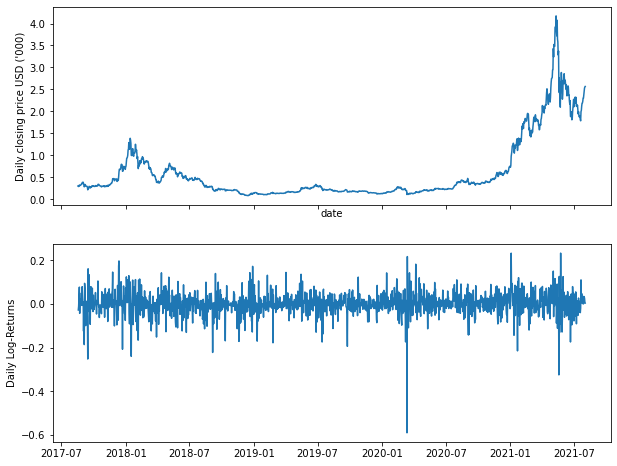

```python
fig, (ax1, ax2) = plt.subplots(2,1, figsize =(10,8), sharex= True)

ax1.plot(df.unix, df.close/1000)
ax2.plot(df.unix, df.logret)
ax1.set_xlabel('date')
ax1.set_ylabel('Daily closing price USD (\'000)')
ax2.set_ylabel('Daily Log-Returns')
```

Using Kolmogorov-Smirnov test, we show that the null hypothesis of a normally distributed log returns were strongly rejected at the 1% signficance level.

Augmented Dickey-Fuller were aslo rejected at 1% significance level, indicating **stationarity** of log returns.

```
Using Kolmogorov-Smirnov test, distribution of daily returns:
 KstestResult(statistic=0.09024448231419963, pvalue=1.051849885265491e-10)

 Using Augmented Dickey-Fuller test, p-value of daily returns: 2.342040493464151e-20
```

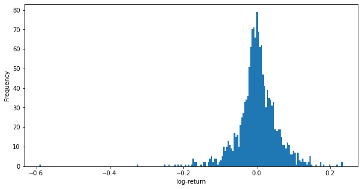

```python
# KS-test
loc, scale = stats.norm.fit(df.logret.dropna())
n = stats.norm(loc=loc, scale = scale)
print(f"Using Kolmogorov-Smirnov test, distribution of daily returns:\n {stats.kstest(df.logret.dropna(), n.cdf)}\n")

# ADF test
from statsmodels. tsa.stattools import adfuller
stationarity = adfuller(df.logret.dropna())
print(f" Using Augmented Dickey-Fuller test, p-value of daily returns: {stationarity[1]}")

fig, (ax) = plt.subplots(1,1, figsize =(10,5), sharex= True)
ax.hist(df.logret, 200)
ax.set_xlabel('log-return')
ax.set_ylabel('Frequency')
```

```python
print(f"Number of positive returns: {df.logret.loc[df.logret > 0].count()}")
print(f"Number of negative returns: {df.logret.loc[df.logret < 0].count()}")
print(f"Mean of positive returns: {df.logret.loc[df.logret > 0].mean()}")
print(f"Mean of negative returns: {df.logret.loc[df.logret < 0].mean()}")
```

```
Number of positive returns: 749
Number of negative returns: 696
Mean of positive returns: 0.037716063841530804
Mean of negative returns: -0.03751331272099177
```

## Hidden Markov Models

Hidden Markov Models is a model where a sequence of observable variables (in this case log returns), is generated by a sequence of internal hidden states m. The m states are not observed directly. The transition between each state i and j is based on the markov assumption: $ P(s_t = j | s_{t-1} = i) = p_{ij}(t) $

where $ p_{ij}(t) = p_{ij}, \forall t$

For an m-state model, we can construct an m x m transition matrix p(t).

In this exercise, we use HMMlearn python library to train the model

```python
df= df.dropna(subset=['volatility','logret'])
obs = df[['logret']].to_numpy()
```

```python
hidden_states = 3
#em_iterations = 1000
#data_length = len(df)
model = hmm.GaussianHMM(n_components = hidden_states, covariance_type = 'full')#, n_iter = em_iterations)
# shape = (n_samples, n_features)
model.fit(obs)
predictions = model.predict(obs)
df['predictions']=pd.Series(predictions)
```

#### Example of a 3-state model

Looking at the volatility values (stdev of log-returns for each regime), volatility clustering can be observed.

```python
def plot_in_sample_hidden_states(hmm_model, df):
    """
    Plot the adjusted closing prices masked by
    the in-sample hidden states as a mechanism
    to understand the market regimes.
    """
    # Create the correctly formatted plot
    fig, axs = plt.subplots(
        hmm_model.n_components, figsize = (10,10)
        #sharex=True, sharey=True
    )
    colours = cm.rainbow(
        np.linspace(0, 1, hmm_model.n_components)
    )
    for i, (ax, colour) in enumerate(zip(axs, colours)):
        mask = predictions == i
        ax.plot_date(
            df['unix'][mask],
            df['close'][mask],
            ".", linestyle='none',
            c=colour
        )
        ax.set_title("Hidden State #%s" % i)
    plt.show()
```

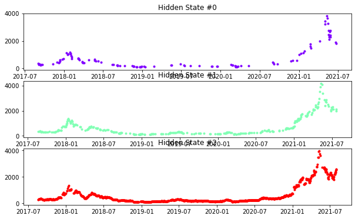

```python
plot_in_sample_hidden_states(model, df)
```

```python
# transition matrix
model.transmat_
```

[output not shown]

```python
print(f"Volatility regimes (Stdev of log ret)")
print(f"Stdev of regime 1: {df['logret'].loc[df.predictions == 0].std()}")
print(f"Stdev of regime 2: {df['logret'].loc[df.predictions == 1].std()}")
print(f"Stdev of regime 3: {df['logret'].loc[df.predictions == 2].std()}")
```

```
Volatility regimes (Stdev of log ret)
Stdev of regime 1: 0.08830073844292434
Stdev of regime 2: 0.05867934251072357
Stdev of regime 3: 0.04951128040873138
```

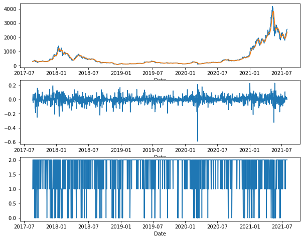

```python
fig, (ax1,ax2,ax3)= plt.subplots(3,1,figsize=(10,8))
ax1.plot(df.unix, df.close)
ax1.plot(df.unix,df.ma10)
ax2.plot(df.unix, df.logret)
ax3.plot(df.unix, df.predictions)
for ax in [ax1,ax2,ax3]:
    ax.set_xlabel("Date")
```

### Goodness-of-fit test

To assess each m-state model, we use 3 information criteria to estimate the information lost by each model.

- Bayesian Information Criterion (BIC): $ k ln(n) - 2 ln(\hat{L})$
- Akaike Information Criterion (AIC): $ 2k - 2 ln(\hat{L})$
- Hannan-Quinn Information Criterion (HQC): $ -2ln(\hat{L}) + 2kln(ln(n))$

```python
def bic_test(likelihood_fn, k, X):
    """ Log term omitted from likelihood_fn(x) because score function from hmmlearn already
    computes the LOG-probability under the model

    Reference:

    https://hmmlearn.readthedocs.io/en/latest/api.html#hmmlearn.base._BaseHMM.score
    """
    return np.log(len(X))*k - 2*likelihood_fn(X)

def aic_test(likelihood_fn, k, X):
    return 2*k - 2 *likelihood_fn(X)

def hqc_test(likelihood_fn, k, X):
    return -2*likelihood_fn(X) + 2 * k * np.log(np.log(len(X)))
```

```python
bic = []
aic = []
hqc = []
m_states = range(2,8)
lowest_bic = np.infty
em_iterations = 100
for hidden_states in m_states:

    model = hmm.GaussianHMM(n_components = hidden_states, covariance_type = 'full', n_iter = em_iterations)
    model.fit(obs) # shape = (n_samples, n_features)
    n_features = model.n_features

    #free parameters = for_means + for_covars + for transmat + for_startprob
    #for means & for_covars = n_features * hidden_states
    free_parameters = 2 * (hidden_states*n_features) + hidden_states*(hidden_states -1) + (hidden_states -1)

    #model score computes the log probability under the model
    bic.append(bic_test(model.score, free_parameters, obs))
    aic.append(aic_test(model.score, free_parameters, obs))
    hqc.append(hqc_test(model.score, free_parameters, obs))
```

Based on the computed AIC, BIC and HQC scores, the model with 3 states appear to have better fit (the lower the better). AIC indicated that the model with 5 states has a better fit than 3-states model.

```python
pd.DataFrame({
    'No. of states': range(2,8),
    'BIC': bic,
    'AIC': aic,
    'HQC': hqc
})
```

|  | No. of states | BIC | AIC | HQC |
| --- | --- | --- | --- | --- |
| 0 | 2 | -4523.701963 | -4560.637858 | -4546.852650 |
| 1 | 3 | -4531.660651 | -4605.532441 | -4577.962025 |
| 2 | 4 | -4478.414264 | -4599.775061 | -4554.480806 |
| 3 | 5 | -4433.334365 | -4612.737283 | -4545.780558 |
| 4 | 6 | -4351.918069 | -4599.916220 | -4507.358394 |
| 5 | 7 | -4260.843053 | -4587.989550 | -4465.891992 |

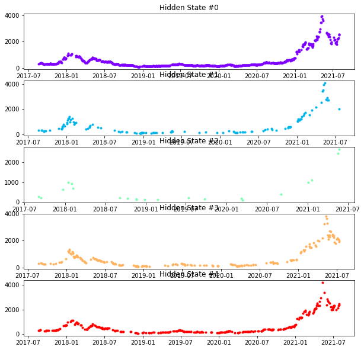

```python
hidden_states = 5

model = hmm.GaussianHMM(n_components = hidden_states, covariance_type = 'full')#, n_iter = em_iterations)
# shape = (n_samples, n_features)
model.fit(obs)
df['predictions']=pd.Series(model.predict(obs))
plot_in_sample_hidden_states(model, df)
```